# The Effects of Borrower and Loan Attributes on Borrower's APR and Loan Outcomes

## by Yiming Zhao

## Investigation Overview

In this investigation, I mainly looked at attributes which may potentially impact Borrower's APR and potential loan outcomes. The main focus was on the loan interest rate, principal amount, loan term, borrower's Prosper score, stated monthly income, and income range.

## Dataset Overview

This dataset consists data of 113,937 loans with 81 variables, including loan amount, borrower rate (or interest rate), current loan status, borrower income, and many others. This explanatory analysis mainly focus on 10 variables.

## Distribution of Borrower's APR

Borrowers APR ranges from almost 0 to 0.5. The distribution of APR takes on a bell shape, with a spike at around 0.35 to 0.36.

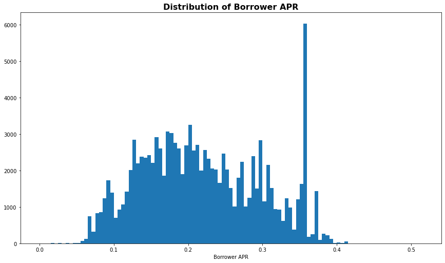

## Distribution of Loan Principal Amount and Borrower's Monthly Income

We notice that most of the borrower's monthly income is within the range of $2500 to $7500, with the distribution skewed to the right. Most of the principal amounts are between $5k - $10k, and the principal is normally distributed, plotted onn a logarithmic scale.

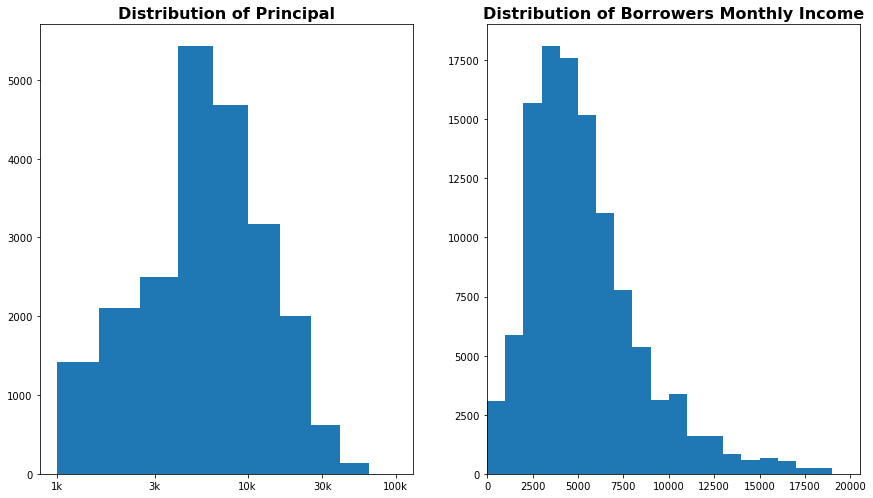

## Attributes that Impact Borrower's APR

### Borrower's APR vs Interest Rate/Estimated Return/Borrower's Credit Score

It appears that borrower's APR, borrower's interest, estimated return, and borrower's credit score are highly correlated with each other. From a borrower's perspective, higher interest rate seems to increase the APR. And borrower with a high credit score will usually have a lower APR. From a lender perspective, higher APR will increase the estimated rate of return for the loan.

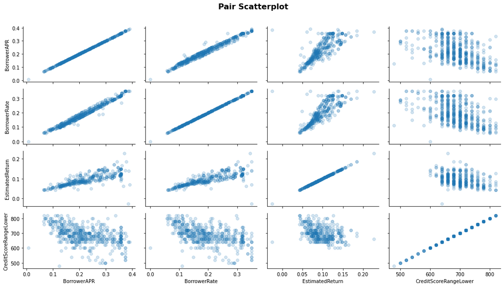

## Attributes that Impact Borrower's APR

### Borrower's APR vs Loan Principal

The scatterplot shows that as the principal amount increases, the borrower's APR descreases. The variables are negatively correlated with each other.

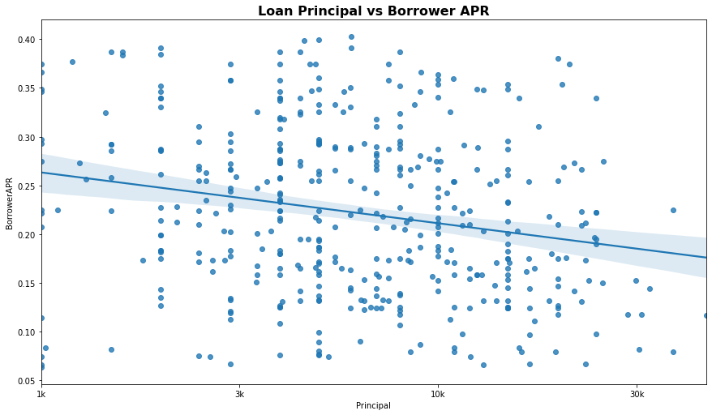

### Estimated Rate of Return vs Loan Principal

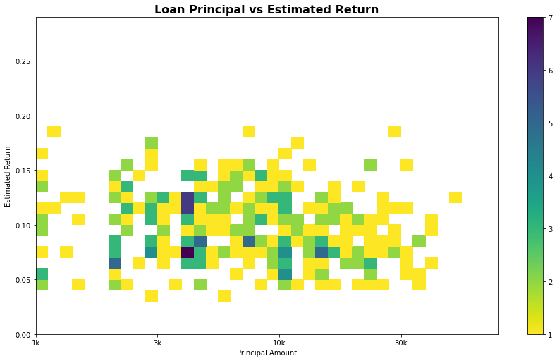

### Estimated Rate of Return vs Prosper Score

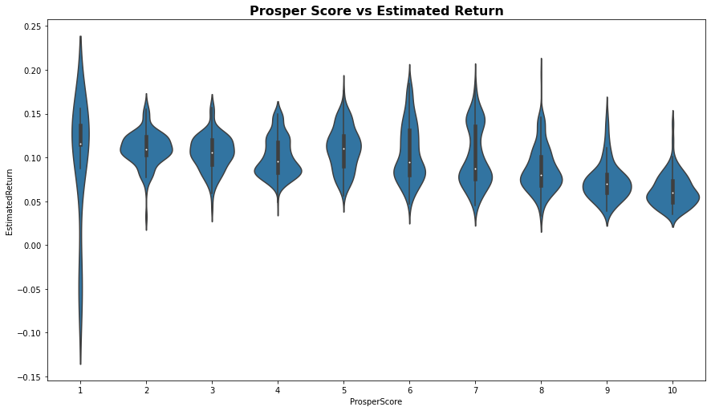

## Loan Outcomes under Different APR and Terms

It also appears that, compared with propser score, the overall effect of loan Term on borrower's APR is smaller.

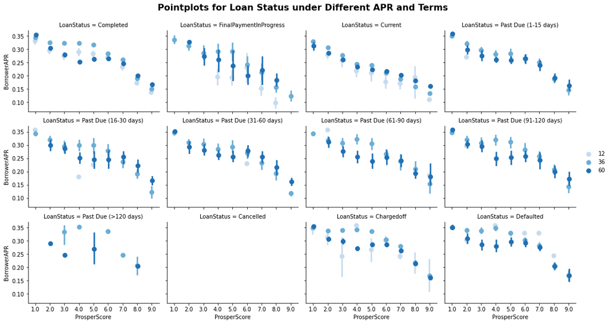

## Factors Impact Loan Size

From the color encoding scatterplot, we notice that there is a roughly positive relationship between monthly income and principal borrowed. Adding the cateogrical vairable "Term", we can see Term 60 associates with more larger size loan, while Term 36 associates with various size of loans.

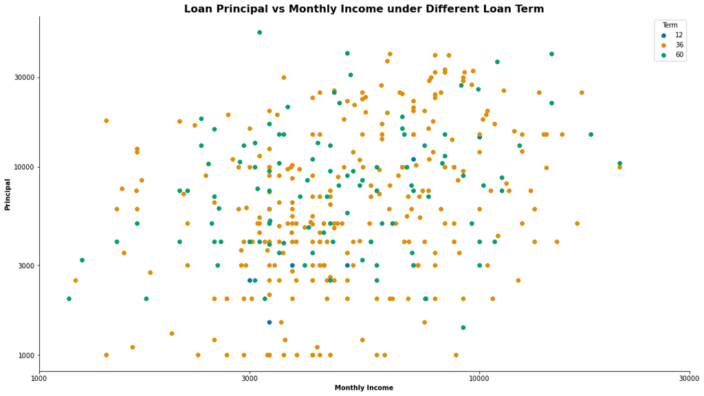